# Hoja de Trabajo #3.1 - Regresiones Lineales

# Nombre: Jose Guillermo Gordillo Lopez

# Carne: 23003971

```r
library(dplyr)
```

# 1. Carga y exploración de datos

```r
path= "auto-mpg.csv"
(df <- read.csv(path))
```

| mpg | cylinders | displacement | horsepower | weight | acceleration | model.year | origin | car.name |
| --- | --- | --- | --- | --- | --- | --- | --- | --- |
| 18.0 | 8 | 307.0 | 130 | 3504 | 12.0 | 70 | 1 | chevrolet chevelle malibu |
| 15.0 | 8 | 350.0 | 165 | 3693 | 11.5 | 70 | 1 | buick skylark 320 |
| 18.0 | 8 | 318.0 | 150 | 3436 | 11.0 | 70 | 1 | plymouth satellite |
| 16.0 | 8 | 304.0 | 150 | 3433 | 12.0 | 70 | 1 | amc rebel sst |
| 17.0 | 8 | 302.0 | 140 | 3449 | 10.5 | 70 | 1 | ford torino |
| 15.0 | 8 | 429.0 | 198 | 4341 | 10.0 | 70 | 1 | ford galaxie 500 |
| 14.0 | 8 | 454.0 | 220 | 4354 | 9.0 | 70 | 1 | chevrolet impala |
| 14.0 | 8 | 440.0 | 215 | 4312 | 8.5 | 70 | 1 | plymouth fury iii |
| 14.0 | 8 | 455.0 | 225 | 4425 | 10.0 | 70 | 1 | pontiac catalina |
| 15.0 | 8 | 390.0 | 190 | 3850 | 8.5 | 70 | 1 | amc ambassador dpl |

[output cut: 388 more lines]

## Examina la estructura de los datos (str(df)).

```r
str(df)
```

```
'data.frame':   398 obs. of  9 variables:
 $ mpg         : num  18 15 18 16 17 15 14 14 14 15 ...
 $ cylinders   : int  8 8 8 8 8 8 8 8 8 8 ...
 $ displacement: num  307 350 318 304 302 429 454 440 455 390 ...
 $ horsepower  : chr  "130" "165" "150" "150" ...
 $ weight      : int  3504 3693 3436 3433 3449 4341 4354 4312 4425 3850 ...
 $ acceleration: num  12 11.5 11 12 10.5 10 9 8.5 10 8.5 ...
 $ model.year  : int  70 70 70 70 70 70 70 70 70 70 ...
 $ origin      : int  1 1 1 1 1 1 1 1 1 1 ...
 $ car.name    : chr  "chevrolet chevelle malibu" "buick skylark 320" "plymouth satellite" "amc rebel sst" ...
```

## Calcula estadísticas descriptivas de las variables mpg , weight y horsepower

```r
summary(df$mpg)
```

```
   Min. 1st Qu.  Median    Mean 3rd Qu.    Max.
   9.00   17.50   23.00   23.51   29.00   46.60
```

```r
summary(df$weight)
```

```
   Min. 1st Qu.  Median    Mean 3rd Qu.    Max.
   1613    2224    2804    2970    3608    5140
```

```r
summary(df$horsepower)
```

```
   Length     Class      Mode
      398 character character
```

- Se puede percatar que las estadisticas descriptivas de la variable “horsepower” no funcionan ya que se interpretan como caracteres

### Se revisa los valores de la variables

```r
#df$horsepower
summary(df)
```

```
      mpg          cylinders      displacement     horsepower        weight      acceleration     model.year
 Min.   : 9.00   Min.   :3.000   Min.   : 68.0   Min.   : 46.0   Min.   :1613   Min.   : 8.00   Min.   :70.00
 1st Qu.:17.50   1st Qu.:4.000   1st Qu.:104.2   1st Qu.: 75.0   1st Qu.:2224   1st Qu.:13.82   1st Qu.:73.00
 Median :23.00   Median :4.000   Median :148.5   Median : 93.5   Median :2804   Median :15.50   Median :76.00
 Mean   :23.51   Mean   :5.455   Mean   :193.4   Mean   :104.5   Mean   :2970   Mean   :15.57   Mean   :76.01
 3rd Qu.:29.00   3rd Qu.:8.000   3rd Qu.:262.0   3rd Qu.:126.0   3rd Qu.:3608   3rd Qu.:17.18   3rd Qu.:79.00
 Max.   :46.60   Max.   :8.000   Max.   :455.0   Max.   :230.0   Max.   :5140   Max.   :24.80   Max.   :82.00
                                                 NA's   :6
     origin        car.name
 Min.   :1.000   Length:398
 1st Qu.:1.000   Class :character
 Median :1.000   Mode  :character
 Mean   :1.573
 3rd Qu.:2.000
 Max.   :3.000
```

### Se convierte en entero los valores remplazandose, advirtiendo que hay valores nulos

```r
df$horsepower <- as.integer(df$horsepower)
```

Se genera un histograma de la variable para ver que tanto afectarian estos valores nulos

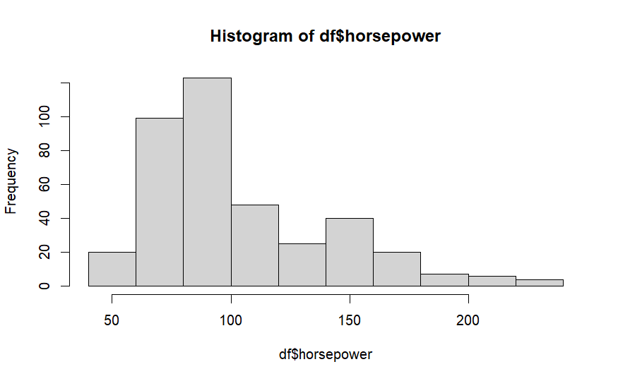

```r
hist(df$horsepower)
```

### Se calcula la media y se remplazan los valores nulos en la variable

```r
# Calcular la media de la columna horsepower excluyendo los NA
media_horsepower <- mean(df$horsepower, na.rm = TRUE)

# Rellenar los NA en la columna horsepower con la media calculada
df$horsepower[is.na(df$horsepower)] <- media_horsepower
```

### Se calculan de nuevo los valores estadisticos y ya todos son numericos

```r
summary(df$mpg)
```

```
   Min. 1st Qu.  Median    Mean 3rd Qu.    Max.
   9.00   17.50   23.00   23.51   29.00   46.60
```

```r
summary(df$weight)
```

```
   Min. 1st Qu.  Median    Mean 3rd Qu.    Max.
   1613    2224    2804    2970    3608    5140
```

```r
summary(df$horsepower)
```

```
   Min. 1st Qu.  Median    Mean 3rd Qu.    Max.
   46.0    76.0    95.0   104.5   125.0   230.0
```

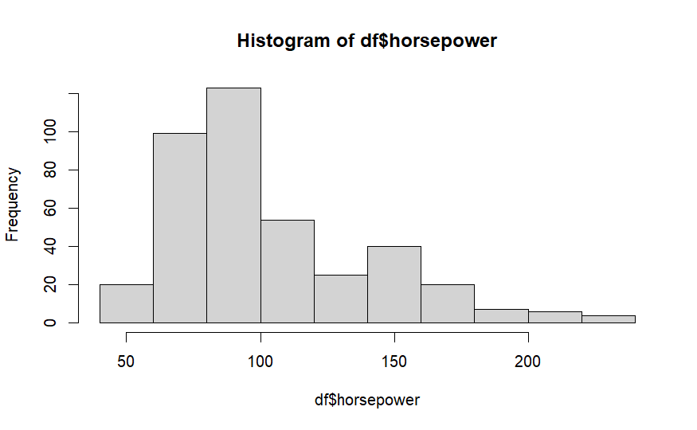

```r
hist(df$horsepower)
```

# 2. Regresión lineal simple

```r
modelo <- lm(mpg ~ weight, data=df)
summary(modelo)
```

```
Call:
lm(formula = mpg ~ weight, data = df)

Residuals:
    Min      1Q  Median      3Q     Max
-12.012  -2.801  -0.351   2.114  16.480

Coefficients:
              Estimate Std. Error t value Pr(>|t|)
(Intercept) 46.3173644  0.7952452   58.24   <2e-16 ***
weight      -0.0076766  0.0002575  -29.81   <2e-16 ***
---
Signif. codes:  0 ‘***’ 0.001 ‘**’ 0.01 ‘*’ 0.05 ‘.’ 0.1 ‘ ’ 1

Residual standard error: 4.345 on 396 degrees of freedom
Multiple R-squared:  0.6918,    Adjusted R-squared:  0.691
F-statistic: 888.9 on 1 and 396 DF,  p-value: < 2.2e-16
```

## 2.1 Interpreta los coeficientes del modelo. ¿Cuál es el efecto estimado del peso sobre el consumo de combustible? ¿Es estadísticamente significativo?

- el intercepto estima que su valor sera de 46.317 cuando la variable independiente peso weight sea cero.
- el otro valor importante es P que tiene un valor de 2e-16 lo que indica que aporta significativamente al modelo
- la variable independiente weight indica que por cada unidad adicional de weight, el mpg disminuye en aproximadamente 0.0076766 unidades. Este coeficiente negativo sugiere que un mayor peso está asociado con una menor eficiencia en combustible
- tambien que esta variable independiente aporta significativamente al modelo al tener un valor de 2e-16

## 2.2 Evalúa la bondad de ajuste del modelo (R cuadrado).

0.6918. Indica que aproximadamente el 69.18% de la variabilidad en mpg se explica por weight.

## 2.3 Realiza un diagnóstico del modelo:

- Crea gráficos de residuos (residuos vs. valores ajustados, residuos vs. weight, histograma de residuos, gráfico Q-Q).

```r
residuos <- residuals(modelo)
```

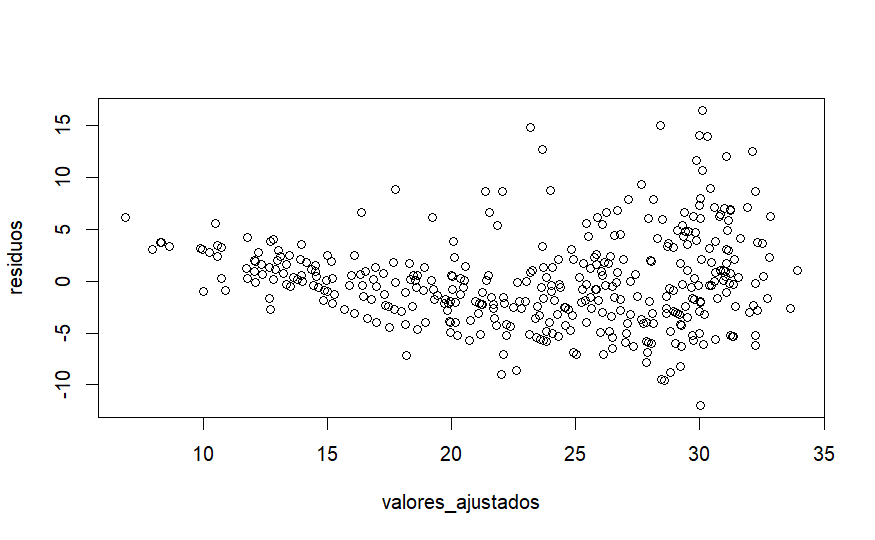

```r
valores_ajustados <- fitted(modelo)

plot(valores_ajustados, residuos)
```

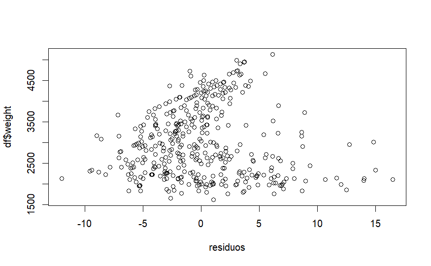

```r
plot(residuos, df$weight)
```

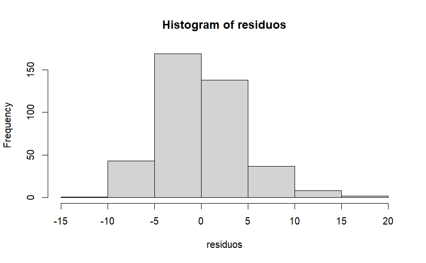

```r
hist(residuos)
```

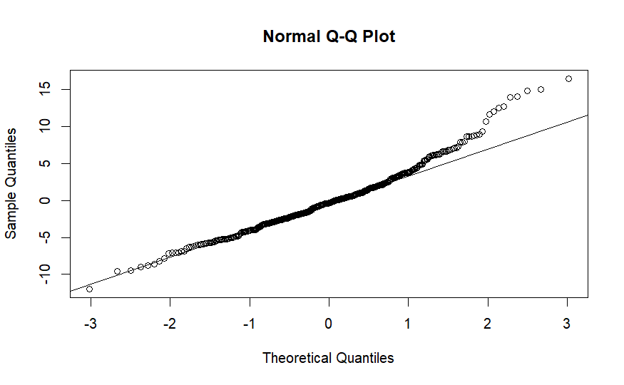

```r
qqnorm(residuos)
qqline(residuos)
```

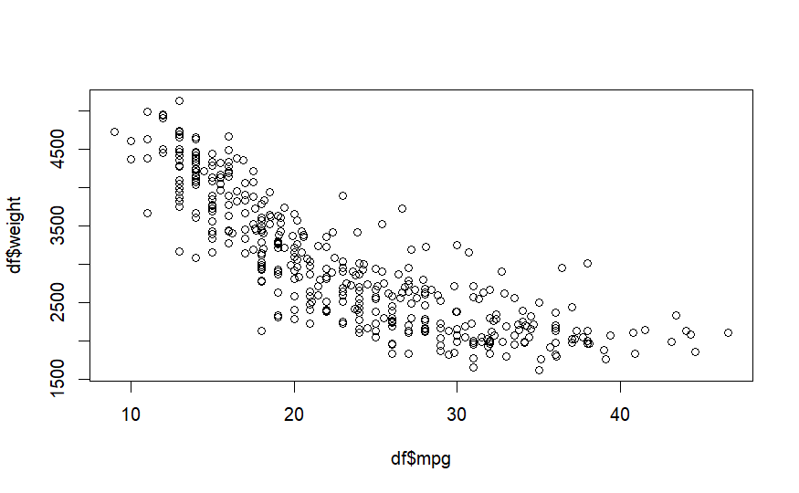

```r
plot(df$mpg ,df$weight)
```

## hay una linealidad negativa en donde entre mas peso tiene un vehiculo la variable mpg es mas pequeño, es logico entre mas pesa mas consumo de combustible, el histograma de residuos nos muestra cierta distribucion normal, se puede ver cierta heterosticidad en la grafica de residuos que se forma un embudo

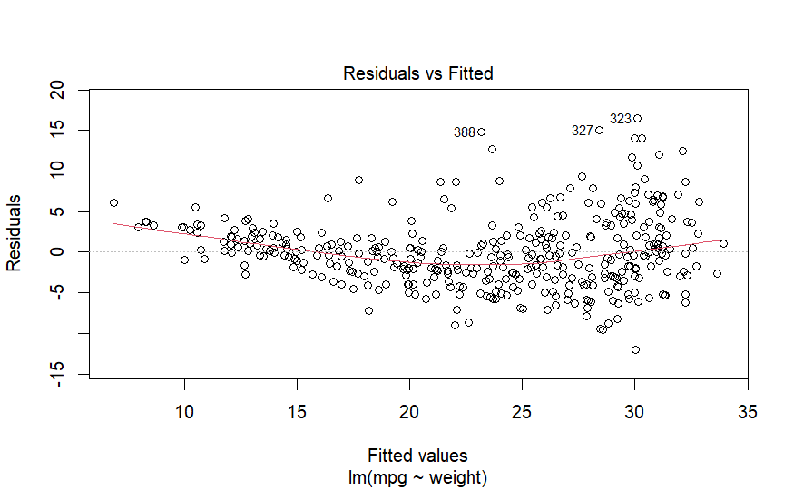

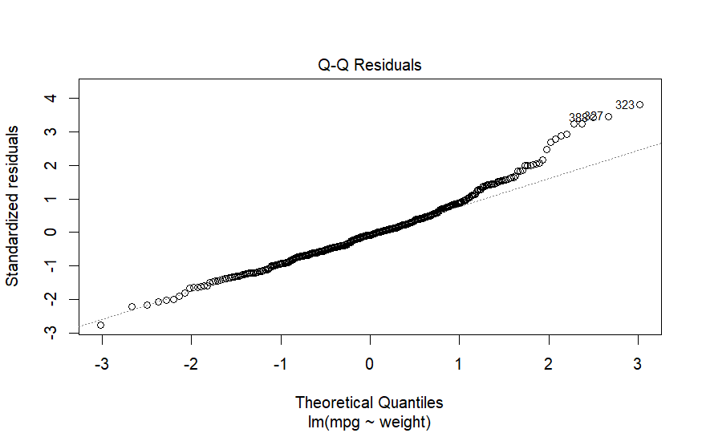

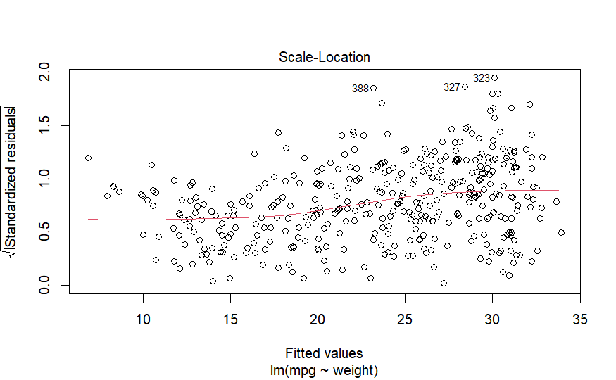

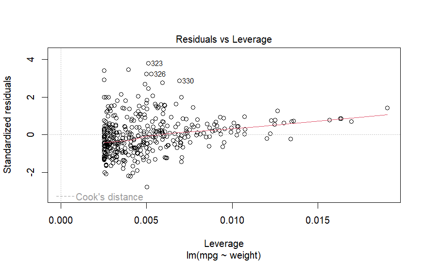

```r
plot(modelo)
```

## 2.4 Si es necesario, aplica transformaciones a la variables (por ejemplo, logaritmo, inversa, etc) para corregir los problemas y vuelve a ajustar el modelo.

- Como se puede observar cierta heterosticidad, se realizara una transformacion

## Transformacion Logaritmica

```r
(logaritmo <- data.frame(mpg = df$mpg, log = log(df$mpg)))
```

| mpg | log |
| --- | --- |
| 18.0 | 2.890372 |
| 15.0 | 2.708050 |
| 18.0 | 2.890372 |
| 16.0 | 2.772589 |
| 17.0 | 2.833213 |
| 15.0 | 2.708050 |
| 14.0 | 2.639057 |
| 14.0 | 2.639057 |
| 14.0 | 2.639057 |
| 15.0 | 2.708050 |

[output cut: 388 more lines]

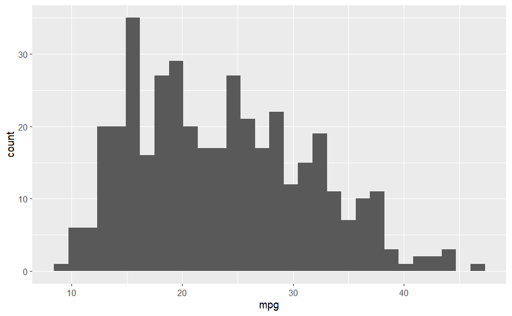

```r
library(ggplot2)

ggplot(data = logaritmo) +
  aes(x = mpg) +
  geom_histogram()
```

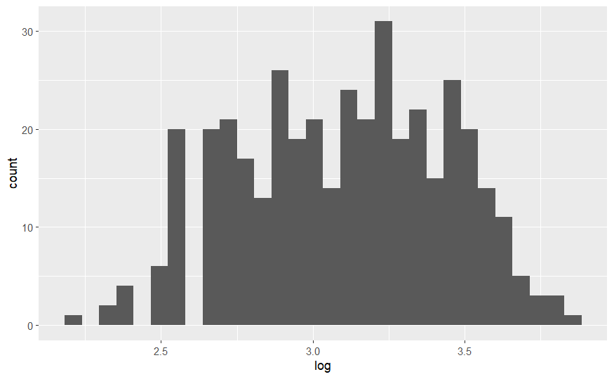

```r
ggplot(data = logaritmo) +
  aes(x = log) +
  geom_histogram()
```

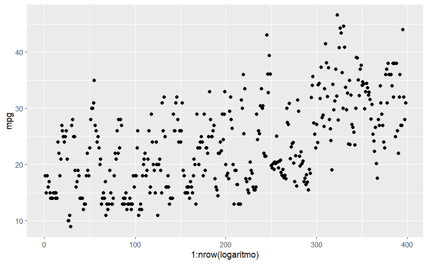

```r
ggplot(data= logaritmo)+
  aes(x = 1:nrow(logaritmo), y=mpg)+
  geom_point()
```

## Transformacion Raiz

```r
(raiz <-  data.frame(mpg= df$mpg,raiz=sqrt(df$mpg)))
```

| mpg | raiz |
| --- | --- |
| 18.0 | 4.242641 |
| 15.0 | 3.872983 |
| 18.0 | 4.242641 |
| 16.0 | 4.000000 |
| 17.0 | 4.123106 |
| 15.0 | 3.872983 |
| 14.0 | 3.741657 |
| 14.0 | 3.741657 |
| 14.0 | 3.741657 |
| 15.0 | 3.872983 |

[output cut: 388 more lines]

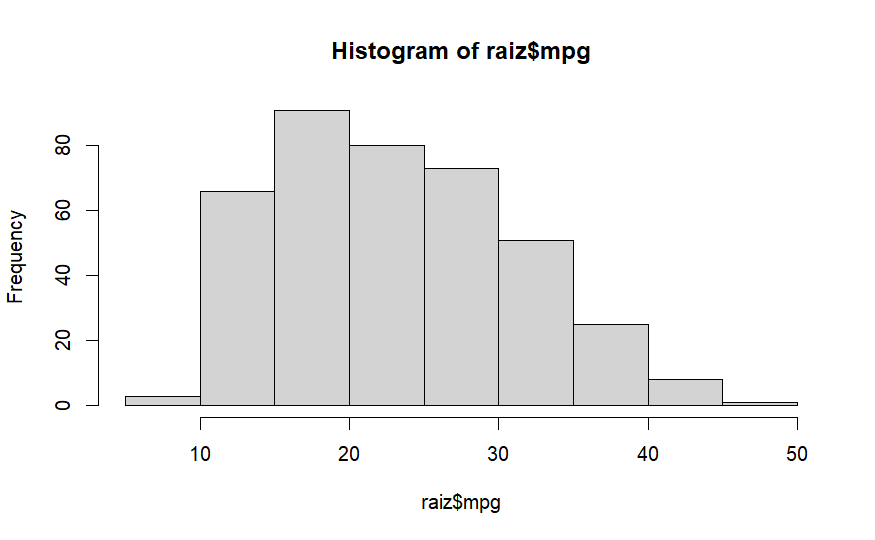

```r
hist(raiz$mpg)
```

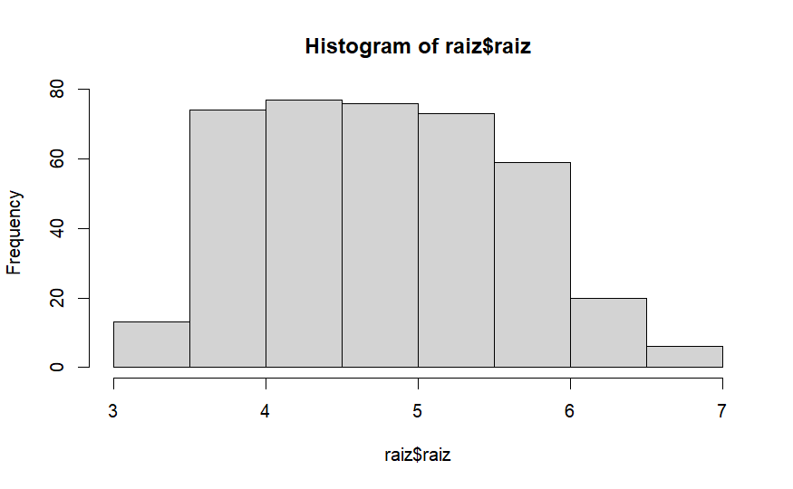

```r
hist(raiz$raiz)
```

## Transformacion Inversa

```r
(inversa <- data.frame(mpg=df$mpg, inver = 1/df$mpg))
```

| mpg | inver |
| --- | --- |
| 18.0 | 0.05555556 |
| 15.0 | 0.06666667 |
| 18.0 | 0.05555556 |
| 16.0 | 0.06250000 |
| 17.0 | 0.05882353 |
| 15.0 | 0.06666667 |
| 14.0 | 0.07142857 |
| 14.0 | 0.07142857 |
| 14.0 | 0.07142857 |
| 15.0 | 0.06666667 |

[output cut: 388 more lines]

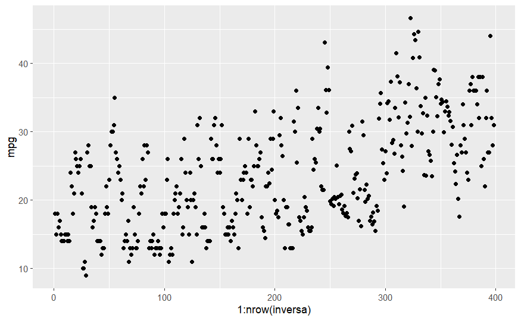

```r
ggplot(data=inversa)+
  aes(x=1:nrow(inversa),y=mpg)+
  geom_point()
```

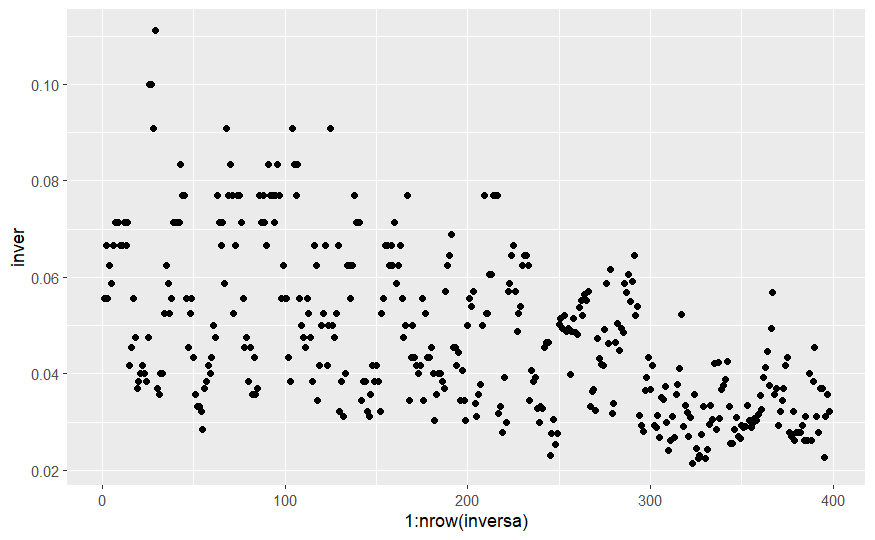

```r
ggplot(data=inversa)+
  aes(x=1:nrow(inversa),y=inver)+
  geom_point()
```

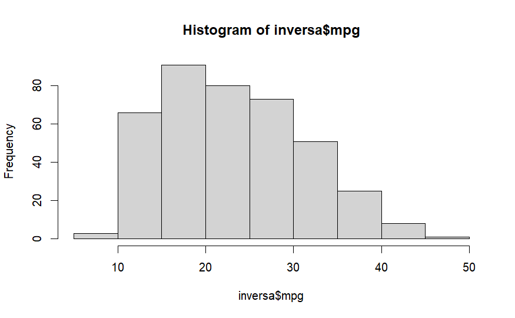

```r
hist(inversa$mpg)
```

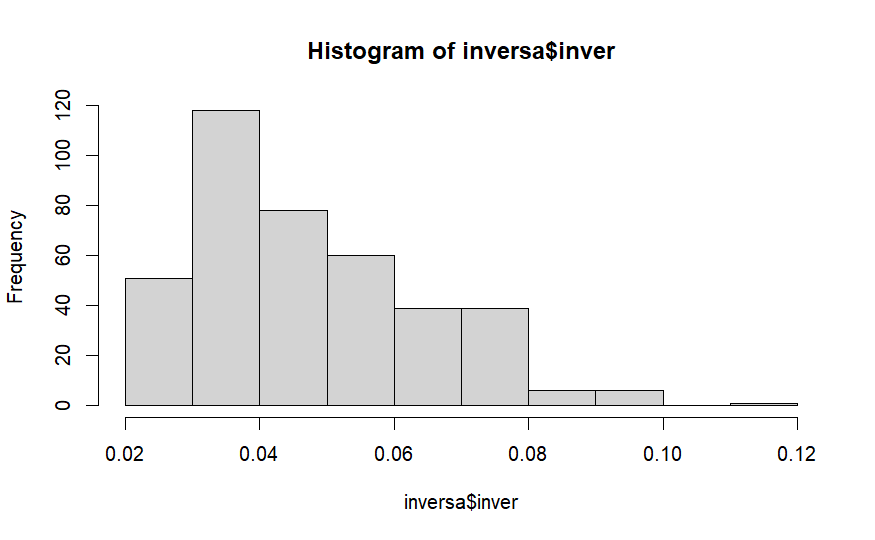

```r
hist(inversa$inver)
```

```r
NA
```

## Transformacion Box-Cox

```r
library(MASS)
```

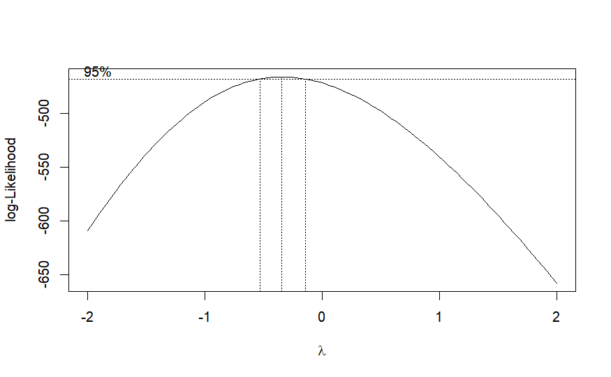

```r
bc <- boxcox(mpg ~ weight,data=df)
```

```r
(verosimilitud_maxima <- which.max(bc$y))
```

```
[1] 42
```

```r
(lambda <- bc$x[verosimilitud_maxima])
```

```
[1] -0.3434343
```

```r
(t_boxcox <- data.frame(mpg=df$mpg, bc = (df$mpg^lambda - 1) / lambda ))
```

| mpg | bc |
| --- | --- |
| 18.0 | 1.832687 |
| 15.0 | 1.762960 |
| 18.0 | 1.832687 |
| 16.0 | 1.788143 |
| 17.0 | 1.811296 |
| 15.0 | 1.762960 |
| 14.0 | 1.735415 |
| 14.0 | 1.735415 |
| 14.0 | 1.735415 |
| 15.0 | 1.762960 |

[output cut: 388 more lines]

```r
print(paste("lambda: ",lambda))
```

```
[1] "lambda:  -0.343434343434343"
```

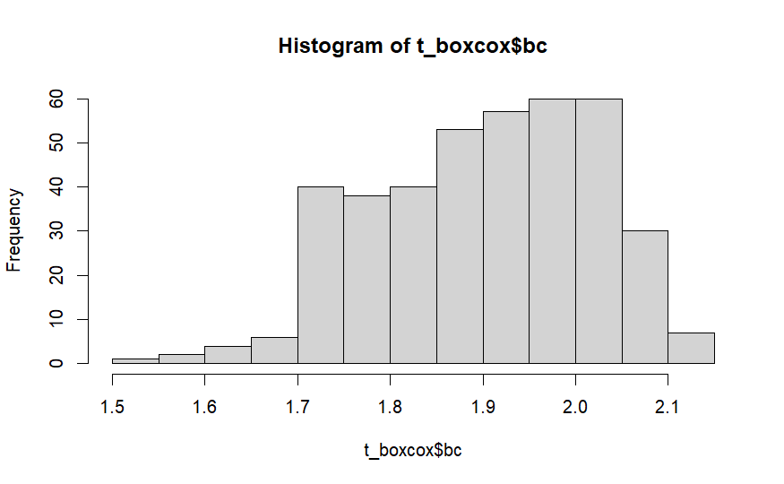

```r
hist(t_boxcox$bc)
```

```r
NA
```

```r
(df <- df %>%
   mutate(mpg_bc = (mpg^lambda-1/lambda)))
```

| mpg | cylinders | displacement | horsepower | weight | acceleration | model.year | origin | car.name | mpg_bc |
| --- | --- | --- | --- | --- | --- | --- | --- | --- | --- |
| 18.0 | 8 | 307.0 | 130.0000 | 3504 | 12.0 | 70 | 1 | chevrolet chevelle malibu | 3.282357 |
| 15.0 | 8 | 350.0 | 165.0000 | 3693 | 11.5 | 70 | 1 | buick skylark 320 | 3.306304 |
| 18.0 | 8 | 318.0 | 150.0000 | 3436 | 11.0 | 70 | 1 | plymouth satellite | 3.282357 |
| 16.0 | 8 | 304.0 | 150.0000 | 3433 | 12.0 | 70 | 1 | amc rebel sst | 3.297655 |
| 17.0 | 8 | 302.0 | 140.0000 | 3449 | 10.5 | 70 | 1 | ford torino | 3.289704 |
| 15.0 | 8 | 429.0 | 198.0000 | 4341 | 10.0 | 70 | 1 | ford galaxie 500 | 3.306304 |
| 14.0 | 8 | 454.0 | 220.0000 | 4354 | 9.0 | 70 | 1 | chevrolet impala | 3.315764 |
| 14.0 | 8 | 440.0 | 215.0000 | 4312 | 8.5 | 70 | 1 | plymouth fury iii | 3.315764 |
| 14.0 | 8 | 455.0 | 225.0000 | 4425 | 10.0 | 70 | 1 | pontiac catalina | 3.315764 |
| 15.0 | 8 | 390.0 | 190.0000 | 3850 | 8.5 | 70 | 1 | amc ambassador dpl | 3.306304 |

[output cut: 388 more lines]

```r
modelo2 <- lm(mpg_bc ~ weight,data=df)
summary(modelo2)
```

```
Call:
lm(formula = mpg_bc ~ weight, data = df)

Residuals:
     Min       1Q   Median       3Q      Max
-0.06223 -0.01230  0.00015  0.01154  0.06233

Coefficients:
             Estimate Std. Error t value Pr(>|t|)
(Intercept) 3.132e+00  3.510e-03  892.52   <2e-16 ***
weight      4.256e-05  1.136e-06   37.45   <2e-16 ***
---
Signif. codes:  0 ‘***’ 0.001 ‘**’ 0.01 ‘*’ 0.05 ‘.’ 0.1 ‘ ’ 1

Residual standard error: 0.01917 on 396 degrees of freedom
Multiple R-squared:  0.7798,    Adjusted R-squared:  0.7793
F-statistic:  1402 on 1 and 396 DF,  p-value: < 2.2e-16
```

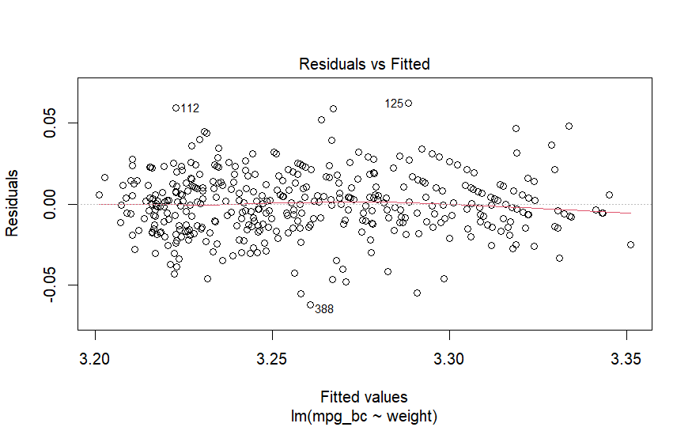

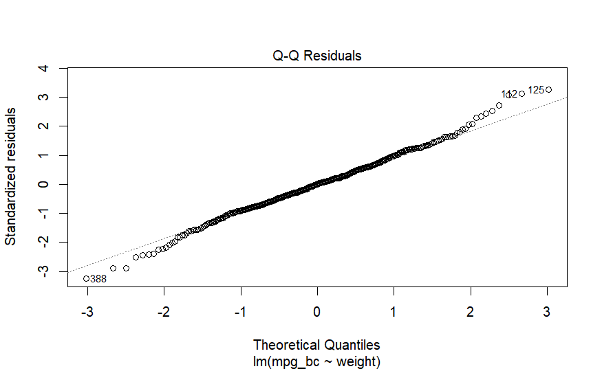

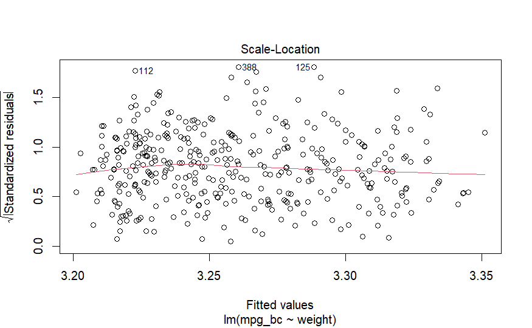

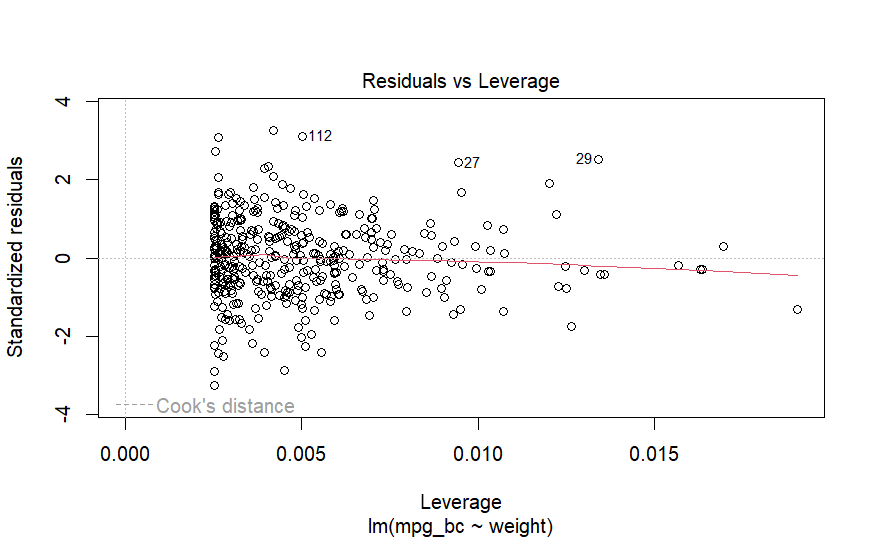

```r
plot(modelo2)
```

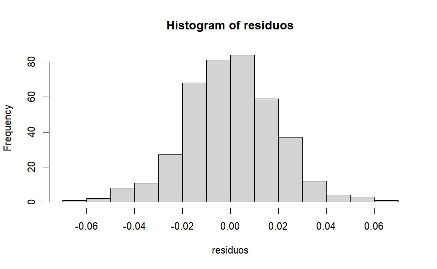

```r
residuos <- residuals(modelo2)
hist(residuos)
```

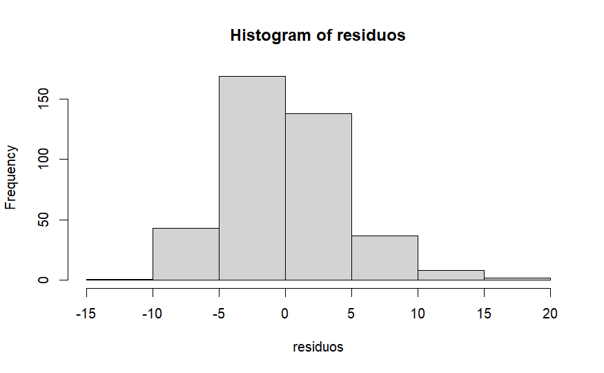

```r
residuos <- residuals(modelo)
hist(residuos)
```

## Se puede observar que ya no hay heterolasticidad en la grafica de residuos y en el de escala se puede apreciar una homolasticidad, asi como el histograma de residuos vemos como la normalidad es mejor al modelo inicial

- con la transformacion de box-cox mejoro bastante el modelo